# Midterm Project: Hedonic Home Price Prediction

### *Yizhou Chen, and Haishan Wu*

## **1 Introduction**

Over the past decade, although it has developed a sophistic housing market prediction method, Zillow is always interested in improving the accuracy of its forecast so that the real estate community can be better served. This project aims to help Zillow to improve the predictive model for the housing market by. One of difficulties for this project is to gather data for all potential predictors. Another difficulty is to determine whether each potential predictor is an effective predictor for home sales price, or it just a factor changes as the home sales price but not a real predictor.

For this project, there are three steps involved in our modeling strategy. First, we gathered data for our predictor. Next, we use ordinary least squares (OLS) regression model. Regression is a statistical measure that attempts to determine the strength of the relationship between a dependent variable (what we try to predict) and one or more predictors (what could explain the dependent variable). From the regression process, we can get a coefficient for each predictor. Eventually, we use the coefficient to predict the home sales price in Boston area.

In summary, we select a total of 17 predictors for our model. The top six predictors according to their level of significance are total number of fire places, the number of full baths in the house appears, distance to MIT, percent of owners occupied houses, the percent of minority, and the spatial lag of home sales price. The average error of the predicted value to the actual observed value is 13% for Boston area. The average error appears to be higher in the relatively rich neighborhoods; however, the average error is lower in the relatively poor neighborhoods.

## **2 Data**

Our data sources come from both Dr. Ken Steif (“Boston_Midterm_Dataset” file), Analyze Boston https://data.boston.gov/ (previously known as Boston Open Data Portal) and ArcGIS Online https://www.arcgis.com/home/index.html.

Dependent Variable: Home Sales Price (Note that dependent variable was log-transformed for calculation purpose)

A List of Predictors and Their Description:

**Home internal characteristics:**  
“YR_REMOD” - Year property was last remodeled  
“R_BLDG_STY” - Residential building style  
“R_ROOF_TYP” - Structure roof type  
“R_EXT_FIN” - Structure exterior finish  
“R_FULL_BTH” - Total number of full baths in the structure  
“R_HALF_BTH” - Total number of half baths in the structure  
“R_AC” - Indicates if the structure has air conditioning  
“R_FPLACE” - Total number of fi replaces in the structure

**Neighborhood features & demographics:**  
“distUniversity” - Weighted distance to Massachusetts Institute of Technology  
“MEDHINC_CY” - Median household income  
“TOTHU_CY” - Total housing units  
“OWNER_CY” - Percent of owner occupied housing units  
“BACHDEG_CY” - Bachelor’s degree  
“GRADDEG_CY” - Graduate/professional degree  
“MINORITYCY” - Percent minority  
“ACSHHBPOV” - Percent households below poverty level

**The underlying spatial structure of prices:**  
“lagprice” - Spatial lag price, which equals to the area of the house (in square footage unit) times the average price per square footage of its nearest ten neighbors.

```
##  [1] "SalePrice"      "YR_REMOD"       "R_BLDG_STY"     "R_ROOF_TYP"
##  [5] "R_EXT_FIN"      "R_FULL_BTH"     "R_HALF_BTH"     "R_AC"
##  [9] "R_FPLACE"       "distUniversity" "lagprice"       "MEDHINC_CY"
## [13] "TOTHU_CY"       "OWNER_CY"       "BACHDEG_CY"     "GRADDEG_CY"
## [17] "MINORITYCY"     "ACSHHBPOV"
```

### 2.1 summary statistics

```r
stargazer(boston.notest, type="text", title = "Summary Statistics")
```

```
##
## Summary Statistics
## ===============================================================
## Statistic        N      Mean      St. Dev.     Min      Max
## ---------------------------------------------------------------
## UniqueSale     1,314   739.376     429.012      1      1,485
## SalePrice      1,314 640,032.900 564,783.800 200,000 11,600,000
## PricePerSq     1,314   296.039     172.956   75.230  2,012.990
## YR_REMOD       1,314  1,950.760    44.913     1,830    2,013
## R_FULL_BTH     1,314    1.992       0.895       1        8
## R_HALF_BTH     1,314    0.358       0.541       0        3
## R_FPLACE       1,314    0.404       0.755       0        5
## Latitude       1,314   42.306       0.038    42.233    42.393
## Longitude      1,314   -71.094      0.043    -71.171  -70.996
## test           1,314    0.000       0.000       0        0
## distUniversity 1,314   0.0002      0.0001    0.0001    0.001
## lagprice       1,314   13.253       0.519    11.697    16.272
## MEDHINC_CY     1,314 70,945.950  31,346.750  14,037   183,726
## TOTHU_CY       1,314   531.699     222.299     46      2,051
## OWNER_CY       1,314    0.452       0.206     0.014    0.913
## BACHDEG_CY     1,314    0.167       0.098     0.000    0.541
## GRADDEG_CY     1,314    0.142       0.116     0.000    0.541
## MINORITYCY     1,314    0.533       0.323     0.021    1.000
## ACSHHBPOV      1,314    0.133       0.111     0.000    0.699
## ---------------------------------------------------------------
```

### 2.2 correlation matrix

The Correlation Matrix allows us to check the independence between predictors, which ensure that predictors are not interfering each other. 0.8 is a general standard for severe correlation between predictors, which means predictors are interfering with each other and our estimation could be wrong. Since all the values of correlation is less than 0.8, we cannot conclude severe correlation between our predictors. All predictors can be included in the model.

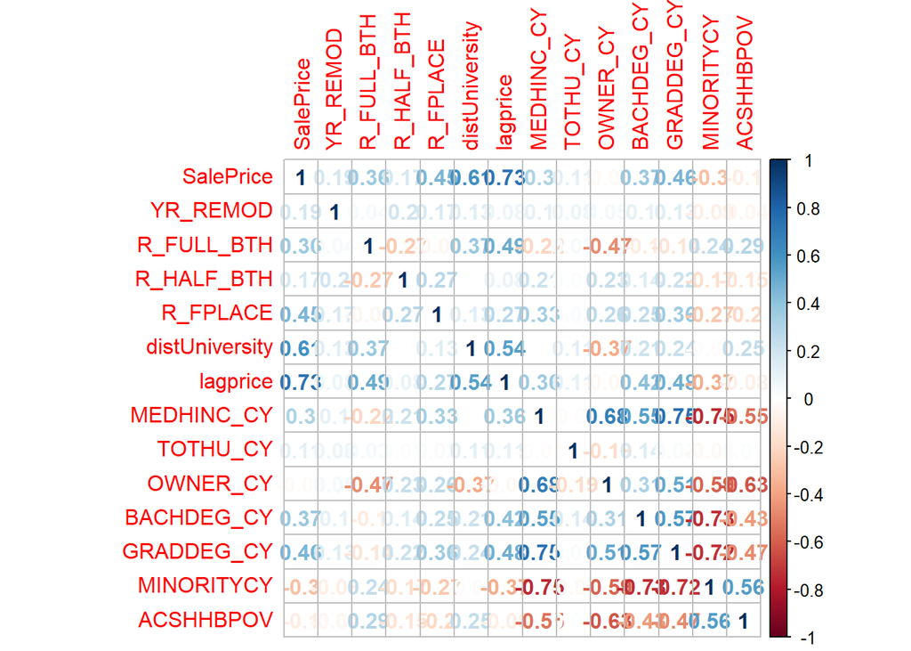

```r
M <- cor(boston.notest %>% select(-c(UniqueSale,Latitude,Longitude,test,R_AC,R_BLDG_STY,
                                     R_ROOF_TYP,R_EXT_FIN,R_AC,PricePerSq,Name)))
corrplot(M, method = "number")
```

### 2.3 dependent variable

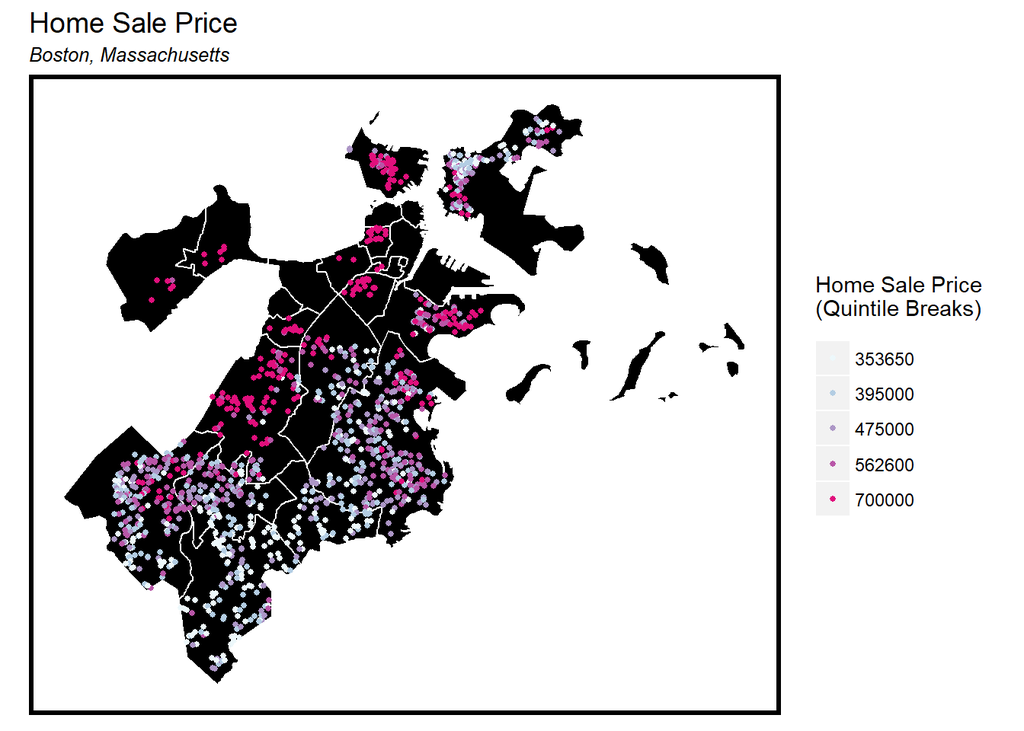

```r
ggplot() +
  geom_sf(data=bostonNhoods, aes(), fill="black", colour="white") +
  geom_point(data=boston.notest,
             aes(Longitude,Latitude, color=factor(ntile(SalePrice,5))),size=1) +
  scale_colour_manual(values = c("#edf8fb","#b3cde3","#ac96c6","#b856a7","#e10f7c"),
                      labels=as.character(quantile(boston.notest$SalePrice,
                                                   c(.1,.2,.4,.6,.8),na.rm=T)),
                      name="Home Sale Price \n(Quintile Breaks)") +
  labs(title="Home Sale Price",
       subtitle="Boston, Massachusetts")+
  mapTheme()
```

### 2.4 independent variables

We are mostly interested in three predictors, including Distance to MIT, Percentage of Minority (by block group) and Spatial Lag of Home Sales Price. The choropleth maps of these three predictors are shown below.

#### distance to MIT

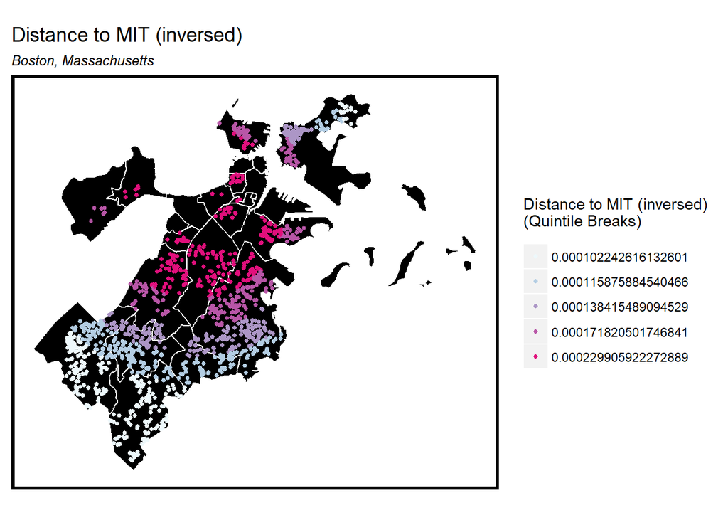

```r
ggplot() +
  geom_sf(data=bostonNhoods, aes(), fill="black", colour="white") +
  geom_point(data=boston.notest,
             aes(Longitude,Latitude, color=factor(ntile(distUniversity,5))),size=1) +
  scale_colour_manual(values = c("#edf8fb","#b3cde3","#ac96c6","#b856a7","#e10f7c"),
                      labels=as.character(quantile(boston.notest$distUniversity,
                                                   c(.1,.2,.4,.6,.8),na.rm=T)),
                      name="Distance to MIT (inversed) \n(Quintile Breaks)") +
  labs(title="Distance to MIT (inversed)",
       subtitle="Boston, Massachusetts")+
  mapTheme()
```

#### percent of minority

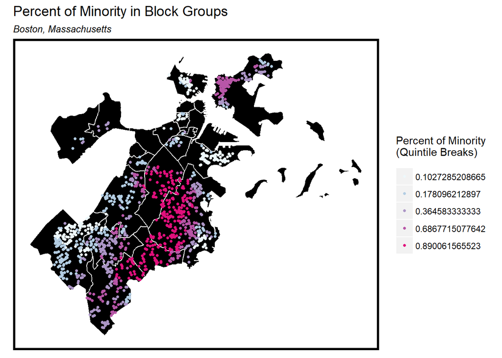

```r
ggplot() +
  geom_sf(data=bostonNhoods, aes(), fill="black", colour="white") +
  geom_point(data=boston.notest,
             aes(Longitude,Latitude, color=factor(ntile(MINORITYCY,5))),size=1) +
  scale_colour_manual(values = c("#edf8fb","#b3cde3","#ac96c6","#b856a7","#e10f7c"),
                      labels=as.character(quantile(boston.notest$MINORITYCY,
                                                   c(.1,.2,.4,.6,.8),na.rm=T)),
                      name="Percent of Minority\n(Quintile Breaks)") +
  labs(title="Percent of Minority in Block Groups",
       subtitle="Boston, Massachusetts")+
  mapTheme()
```

#### spatial lagged sale price

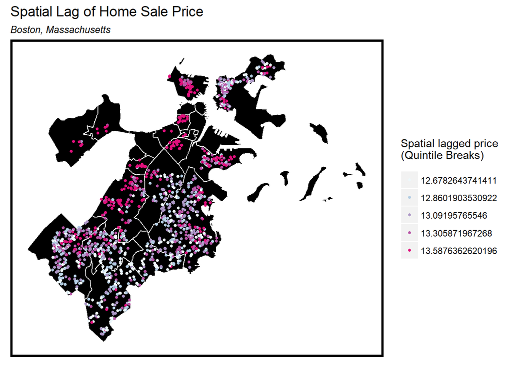

```r
ggplot() +
  geom_sf(data=bostonNhoods, aes(), fill="black", colour="white") +
  geom_point(data=boston.notest,
             aes(Longitude,Latitude, color=factor(ntile(lagprice,5))),size=1) +
  scale_colour_manual(values = c("#edf8fb","#b3cde3","#ac96c6","#b856a7","#e10f7c"),
                      labels=as.character(quantile(boston.notest$lagprice,
                                                   c(.1,.2,.4,.6,.8),na.rm=T)),
                      name="Spatial lagged price\n(Quintile Breaks)") +
  labs(title="Spatial Lag of Home Sale Price",
       subtitle="Boston, Massachusetts")+
  mapTheme()
```

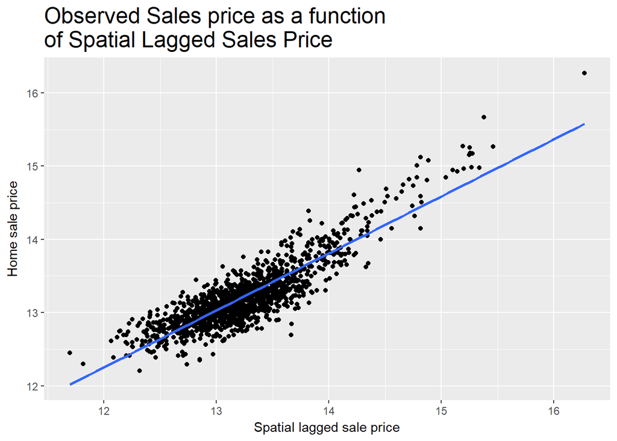

```r
ggplot()+
  geom_point(data = boston.notest,aes(x=lagprice,y=log(SalePrice)))+
  stat_smooth(data = boston.notest,aes(x=lagprice,y=log(SalePrice)), method = "lm", se = FALSE, size = 1) +
  labs(title="Observed Sales price as a function\nof Spatial Lagged Sales Price",
       y="Home sale price",
       x="Spatial lagged sale price") +
  theme(plot.title = element_text(size = 18,colour = "black"))
```

The scatterplot above shows that as the home sales price (log(SalePrice)) increase, the average home sales price in the neighborhood (lagprice) increase.

## **3 Methods**

Knowing that our dependent variable is Home Sales Prices, we start with testing 30 different potential predictors from three categories – internal characteristics, neighborhood features & demographics, the underlying spatial structure of housing prices. Then, we go into an elimination process based on the possibility of each potential predictor being an actual predictor of Home Sales Prices. Meanwhile, we perform cross validation test, a model validation technique, to verify the difference between the predicted values by our model and the actual observed values. The more effective the predictor is, the higher level of significance shows in the outcome; the closer the predicted values are to the actual observed values, the smaller difference we have between these two values. The goal is to choose the most effective predictors and build a model that has predicted values closest to the observed values. Finally, we have our best selected predictors and predictive model.

## **4 Results**

### 4.1 Regression summary

Firstly, we randomly select 75% of the dataset as training set, which is used to build our model. The other 25% dataset is used as test set for testing the model to check how it performs on new unseen versions of the same classes. We predict the home sales price (the dependent variable log(SalePrice)) with selected predictors (17 selected predictors listed above) through OLS regression. The results are shown as below.

```r
inTrain <- createDataPartition(
  y = boston.notest$SalePrice,
  p = .75, list = FALSE)
training <- boston.notest[inTrain,] #the new training set
test <- boston.notest[-inTrain,]  #the new test set

reg <- lm(log(SalePrice) ~.,data = training %>% select(-c(UniqueSale,Latitude,Longitude,test,PricePerSq,Name)))
```

```r
summary(reg)
```

```
##
## Call:
## lm(formula = log(SalePrice) ~ ., data = training %>% select(-c(UniqueSale,
##     Latitude, Longitude, test, PricePerSq, Name)))
##
## Residuals:
##      Min       1Q   Median       3Q      Max
## -0.52742 -0.09692 -0.00435  0.10814  0.67660
##
## Coefficients:
##                      Estimate     Std. Error t value             Pr(>|t|)
## (Intercept)      6.1474022783   0.3688643385  16.666 < 0.0000000000000002
## YR_REMOD         0.0003725946   0.0001269535   2.935             0.003418
## R_BLDG_STYCL     0.0610231990   0.0373073222   1.636             0.102239
## R_BLDG_STYCP     0.0432380459   0.0400378103   1.080             0.280450
## R_BLDG_STYCV     0.0232033971   0.0401619432   0.578             0.563574
## R_BLDG_STYDK     0.0751014412   0.0473570547   1.586             0.113108
## R_BLDG_STYDX    -0.0843385910   0.0642167482  -1.313             0.189387
## R_BLDG_STYRE     0.0253698439   0.0478522822   0.530             0.596119
## R_BLDG_STYRM     0.0714330693   0.0485973739   1.470             0.141924
## R_BLDG_STYRN     0.0347425920   0.0479965970   0.724             0.469334
## R_BLDG_STYRR    -0.0843651599   0.0538659225  -1.566             0.117636
## R_BLDG_STYSD    -0.0352678327   0.0447100582  -0.789             0.430420
## R_BLDG_STYSL    -0.0176998999   0.0722198241  -0.245             0.806445
## R_BLDG_STYTF     0.0145158818   0.0407496065   0.356             0.721755
## R_BLDG_STYTL    -0.0700677805   0.1682305427  -0.416             0.677140
## R_BLDG_STYVT     0.0105998603   0.0824889179   0.129             0.897780
## R_ROOF_TYPG     -0.0024798550   0.0218914540  -0.113             0.909833
## R_ROOF_TYPH      0.0410824064   0.0257803689   1.594             0.111371
## R_ROOF_TYPL      0.0331390641   0.0382840809   0.866             0.386925
## R_ROOF_TYPM      0.0295599685   0.0274273501   1.078             0.281419
## R_ROOF_TYPS      0.1155977866   0.0969668665   1.192             0.233508
## R_EXT_FINB       0.1290232320   0.0330091819   3.909    0.000099435626482
## R_EXT_FINC       0.0596794151   0.0780361938   0.765             0.444603
## R_EXT_FINF       0.0499510924   0.0306474478   1.630             0.103465
## R_EXT_FINM       0.0091067441   0.0248074141   0.367             0.713629
## R_EXT_FINP      -0.0519484262   0.0446074550  -1.165             0.244489
## R_EXT_FINS      -0.0320863963   0.0665577812  -0.482             0.629859
## R_EXT_FINU       0.3774732716   0.1646200607   2.293             0.022068
## R_EXT_FINV       0.3024555705   0.1662688358   1.819             0.069217
```

[output cut: 51 more lines]

```
## distUniversity ***
## lagprice       ***
## MEDHINC_CY     **
## TOTHU_CY       .
## OWNER_CY       ***
## BACHDEG_CY     ***
## GRADDEG_CY     ***
## MINORITYCY     ***
## ACSHHBPOV
## ---
## Signif. codes:  0 '***' 0.001 '**' 0.01 '*' 0.05 '.' 0.1 ' ' 1
##
## Residual standard error: 0.1621 on 942 degrees of freedom
## Multiple R-squared:  0.8808, Adjusted R-squared:  0.8754
## F-statistic: 161.9 on 43 and 942 DF,  p-value: < 0.00000000000000022
```

Secondly, we look at some important statistical measures to evaluate the performance of our model.

R-squared represents the proportion of variance in home sales price (the dependent variable) that has been explained by the regression model, so it is more desirable to achieve a higher value of R-squared. We have a relatively higher value of R-squared for the training set 0.9284 than that of the test set 0.8976, which means that variance in home sales price is more well-explained in the training set than the test set.

Root mean square error (RMSE), mean absolute error (MAE) and mean absolute percent error (MAPE) are frequently used measures of the differences between predicted values and the observed values. We see a discrepancy in training set and test set for the values of RMSE, MAE and MAPE. The predicted values are closer to the actual observed values in training set than in test set.

The inconsistencies between training set and test set in the above-mentioned measures indicate that the current model is not performing as well on an unknown dataset as on a known dataset. We should improve our model and make it more generalizable.

```r
reg.trainingset <- data.frame(observed=training$SalePrice,
                              predicted=exp(reg$fitted.values))
reg.trainingset <- reg.trainingset %>%
  mutate(error=predicted-observed,
         squareError=error^2,
         absError=abs(error),
         absPctError=absError/observed)
rsquared.training <- 1-(sum(reg.trainingset$squareError)/sum((reg.trainingset$observed-mean(reg.trainingset$observed))^2))
rmse.training <- (mean(reg.trainingset$squareError))^(1/2)
mae.training <- MAE(reg.trainingset$predicted,reg.trainingset$observed)
mape.training <- mean(reg.trainingset$absPctError)

reg.testset <- data.frame(observed=test$SalePrice,
                          predicted=exp(predict(reg,test)))
reg.testset <- reg.testset %>%
  mutate(error=predicted-observed,
         squareError=error^2,
         absError=abs(error),
         absPctError=absError/observed)
rsquared.test <- 1-(sum(reg.testset$squareError)/sum((reg.testset$observed-mean(reg.testset$observed))^2))
rmse.test <- (mean(reg.testset$squareError))^(1/2)
mae.test <- MAE(reg.testset$predicted,reg.testset$observed)
mape.test <- mean(reg.testset$absPctError)

reg.trainingset.summary <- data.frame(dataset=c("training","test"),
                                      Rsquared=c(rsquared.training,rsquared.test),
                                      RMSE=c(rmse.training,rmse.test),
                                      MAE=c(mae.training,mae.test),
                                      MAPE=c(mape.training,mape.test))

reg.trainingset.summary1 <- gather(reg.trainingset.summary,statistics,value,-dataset)
```

```r
reg.trainingset.summary
```

```
##    dataset  Rsquared     RMSE      MAE      MAPE
## 1 training 0.9284139 155705.4 82418.15 0.1249810
## 2     test 0.8975973 162724.3 90334.94 0.1402226
```

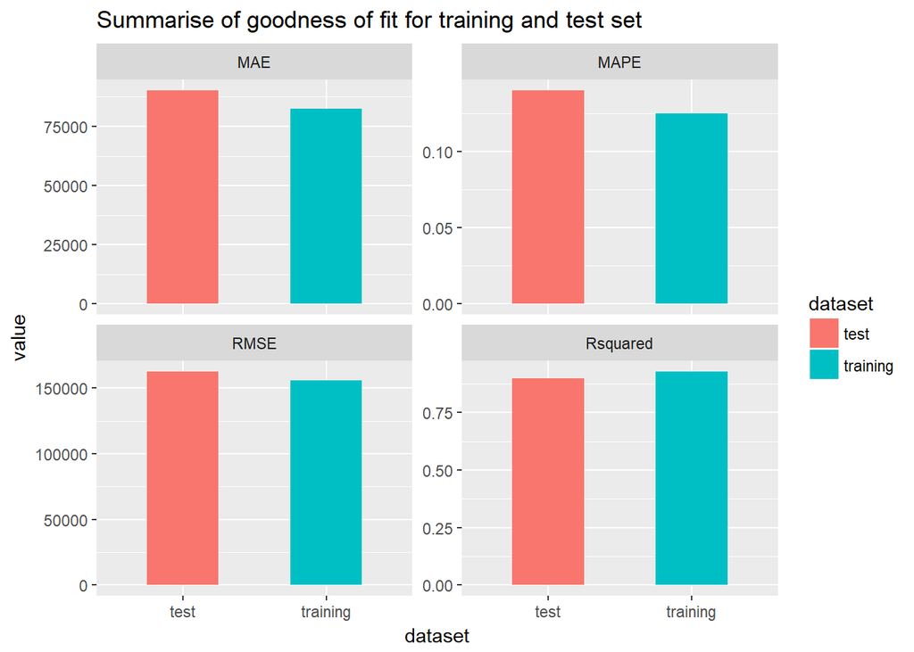

```r
ggplot(data = reg.trainingset.summary1,aes(x=dataset,y=value))+
  geom_col(aes(fill=dataset),width = .5) +
  facet_wrap(~statistics,scales = "free_y")+
  labs(title="Summarise of goodness of fit for training and test set")
```

### 4.2 Cross-validation result

To further examine the extent of generalizability of our model, we randomly partition the training into 10 equal sized groups (statistically known as “folds”). Each group, or fold, is treated as a validation data set (to test the predictability of the model), and the remaining folds are treated as a training data set (to estimate the model of interest, such as, parameters). After repeating this process for 10 times, we have a value of 10-fold RMSE to estimate the different the predicted values and the actual values. Generally, we expect relatively low RMSE in this test to help us determining the final regression model.

```r
fitControl <- trainControl(method = "cv", number = 10)
set.seed(825)

lmFit <- train(log(SalePrice) ~.,
                data = training %>% select(-c(UniqueSale,Latitude,Longitude,test,PricePerSq,Name)),
                method = "lm",
                trControl = fitControl)
```

```r
lmFit
```

```
## Linear Regression
##
## 986 samples
##  18 predictor
##
## No pre-processing
## Resampling: Cross-Validated (10 fold)
## Summary of sample sizes: 886, 887, 887, 887, 887, 887, ...
## Resampling results:
##
##   RMSE       Rsquared   MAE
##   0.1646115  0.8621539  0.1278717
##
## Tuning parameter 'intercept' was held constant at a value of TRUE
```

```r
lmFit1$resample
```

```
##         RMSE  Rsquared       MAE Resample
## 1  0.1634859 0.8260621 0.1280704   Fold01
## 2  0.1471539 0.8949351 0.1156185   Fold02
## 3  0.1831668 0.8201661 0.1365797   Fold03
## 4  0.1459037 0.8943786 0.1118841   Fold04
## 5  0.1734019 0.8707096 0.1361648   Fold05
## 6  0.1820463 0.8518269 0.1440880   Fold06
## 7  0.1868806 0.8607875 0.1424119   Fold07
## 8  0.1619669 0.9057041 0.1248560   Fold08
## 9  0.1826166 0.8310478 0.1434337   Fold09
## 10 0.1805605 0.8184067 0.1397332   Fold10
```

```r
mean(lmFit1$resample$Rsquared)
```

```
## [1] 0.8574025
```

```r
sd(lmFit1$resample$Rsquared)
```

```
## [1] 0.03318737
```

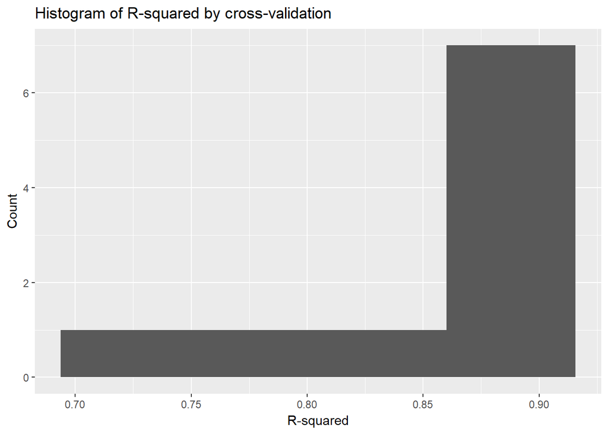

```r
ggplot(as.data.frame(lmFit$resample), aes(Rsquared)) +
  geom_histogram(bins=4) +
  labs(x="R-squared",
       y="Count",
       title="Histogram of R-squared by cross-validation")
```

### 4.3 Test for residuals

Furthermore, we do some testing for regression residuals. The values of residuals indicate the error between the predicted values and the actual observed values. It is preferred for residual values to be closed to zero, which means the error of the model is very small.

The following two plots are The Regression Residuals as a Function of Observed Values and The Regression Residuals as a Function of Predicted Values. From both plots, the residual values cluster closely to zero when the observed values and the predicted values are low; however, the residual values are high when the observed values and the predicted values are high. This phenomenon reveals that our model’s performance is inconsistent for different levels of home sales price.

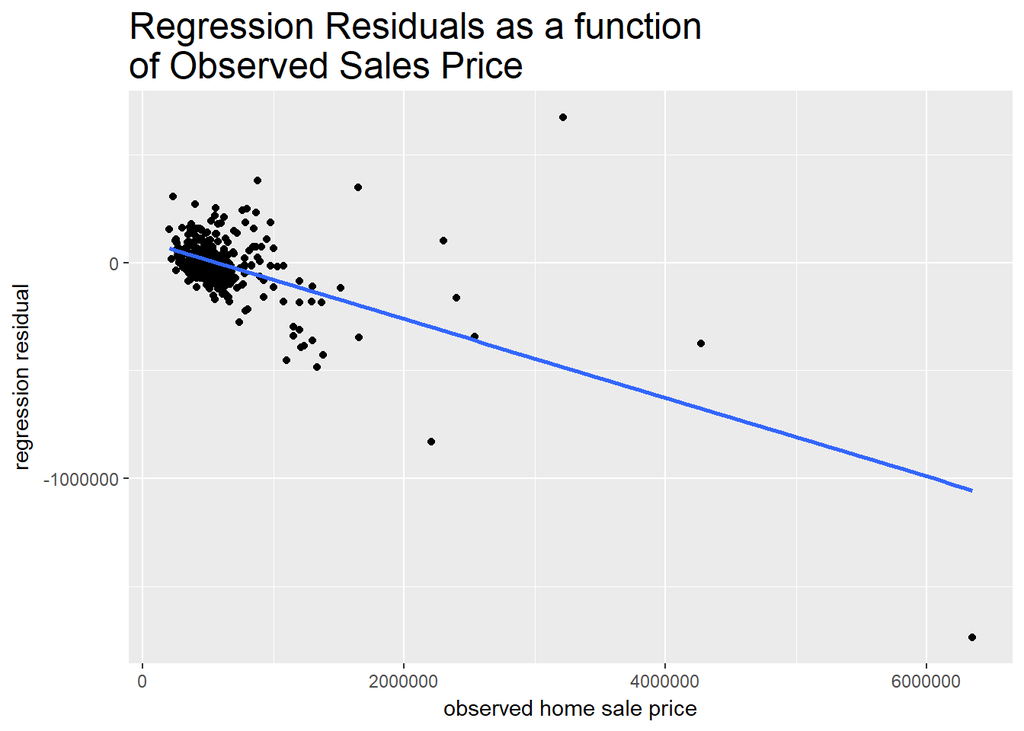

```r
ggplot() +
  geom_point(data=reg.testset, aes(observed, error)) +
  stat_smooth(data=reg.testset, aes(observed, error), method = "lm", se = FALSE, size = 1) +
  labs(title="Regression Residuals as a function\nof Observed Sales Price",
       x="observed home sale price",
       y="regression residual") +
  theme(plot.title = element_text(size = 18,colour = "black"))
```

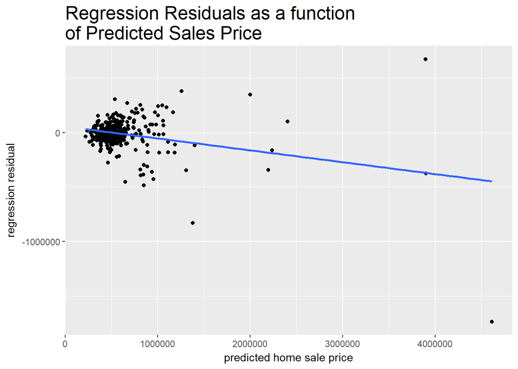

```r
ggplot() +
  geom_point(data=reg.testset, aes(predicted, error)) +
  stat_smooth(data=reg.testset, aes(predicted, error), method = "lm", se = FALSE, size = 1) +
  labs(title="Regression Residuals as a function\nof Predicted Sales Price",
       x="predicted home sale price",
       y="regression residual") +
  theme(plot.title = element_text(size = 18,colour = "black"))
```

Also, we look at the spatial distribution of the residuals to test if there is any spatial pattern that is not explained by the model. We do not see any strong spatial pattern of clustering or dispersing in residuals from the residuals map of test set, except for few neighborhoods with small amount of observations.

In addition, Moran’s I test is run to account for spatial autocorrelation statistically. It is preferred for the value of moran’s I to be closed to zero, because it indicates spatial randomness of the residuals. We have a moran’s I value of -0.04522, so we may conclude that our model is doing a good job in explaining the underlying spatial structure of sales price.

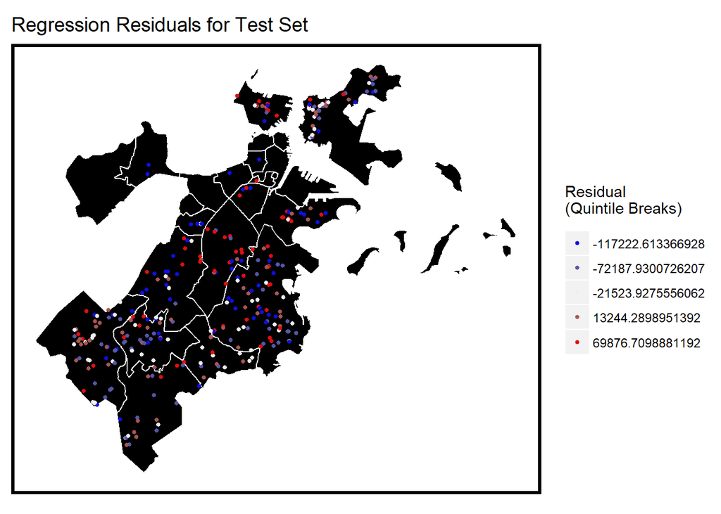

```r
ggplot() +
  geom_sf(data=bostonNhoods, aes(), fill="black", colour="white") +
  geom_point(aes(test$Longitude,test$Latitude, color=factor(ntile(reg.testset$error,5))),size=1) +
  scale_colour_manual(values = c("#0f0fe1","#5656a8","#eeeeee","#a85656","#e10f0f"),
                      labels=as.character(quantile(reg.testset$error,
                                                   c(.1,.2,.4,.6,.8),na.rm=T)),
                      name="Residual\n(Quintile Breaks)") +
  labs(title="Regression Residuals for Test Set")+
  mapTheme()
```

```r
coords <- cbind(test$Longitude,test$Latitude)
spatialWeights <- knn2nb(knearneigh(coords, 4))
moran.test(reg.testset$error, nb2listw(spatialWeights, style="W"))
```

```
##
##  Moran I test under randomisation
##
## data:  reg.testset$error
## weights: nb2listw(spatialWeights, style = "W")
##
## Moran I statistic standard deviate = -1.2387, p-value = 0.8923
## alternative hypothesis: greater
## sample estimates:
## Moran I statistic       Expectation          Variance
##      -0.045224575      -0.003058104       0.001158762
```

### 4.4 Results by neighborhood

The following two maps of predicted values and mean absolute percent error by neighborhood allow us to examine if our model performance varies across neighborhoods.

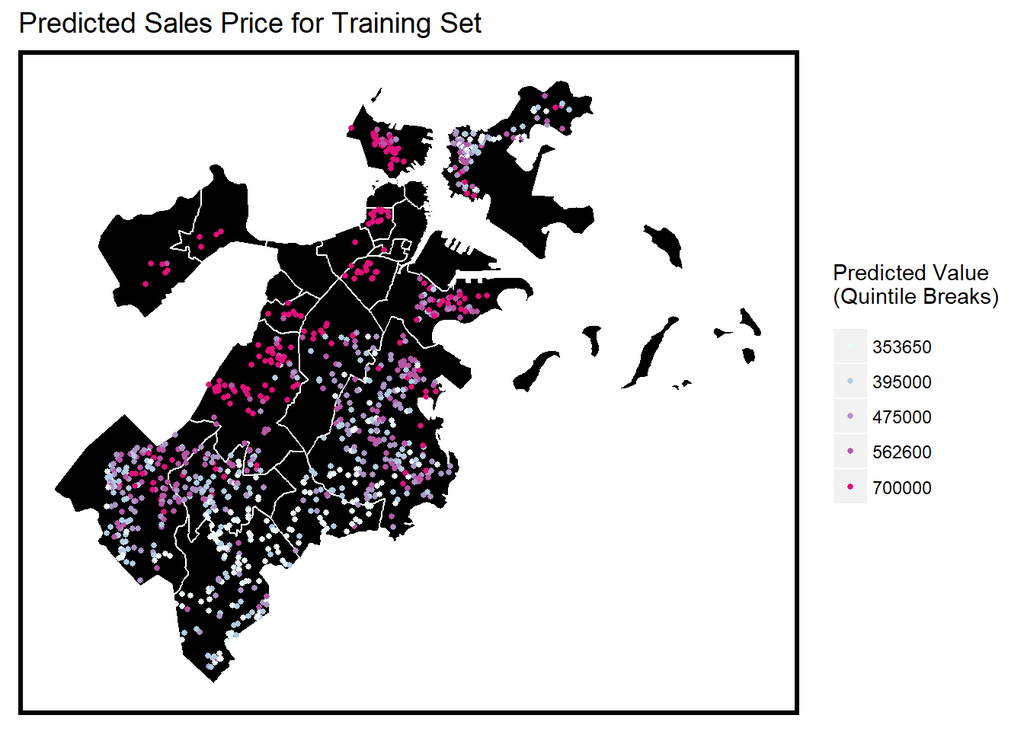

```r
ggplot() +
  geom_sf(data=bostonNhoods, aes(), fill="black", colour="white") +
  geom_point(aes(training$Longitude,training$Latitude, color=factor(ntile(reg$fitted.values,5))),size=1) +
  scale_colour_manual(values = c("#edf8fb","#b3cde3","#ac96c6","#b856a7","#e10f7c"),
                      labels=as.character(quantile(boston.notest$SalePrice,
                                                   c(.1,.2,.4,.6,.8),na.rm=T)),
                      name="Predicted Value\n(Quintile Breaks)") +
  labs(title="Predicted Sales Price for Training Set")+
  mapTheme()
```

As mentioned above, the value of MAPE is determined by the percentage differences between predicted values and the observed values, so a relatively low MAPE value is preferred. According to the map, the relatively high MAPE values occur in in some rich neighborhoods (neighborhoods with higher home sales price) such as Downtown and Back Bay. The relatively high MAPE values once again suggest that our model is not performing as well in rich neighborhoods compared to other neighborhoods.

```r
error.Neighborhood <- data.frame(Name=training$Name,
                                 APE=reg.trainingset$absPctError) %>%
  group_by(Name) %>%
  summarise(MAPE=mean(APE)) %>%
  left_join(bostonNhoods,by="Name") %>%
  st_sf()
```

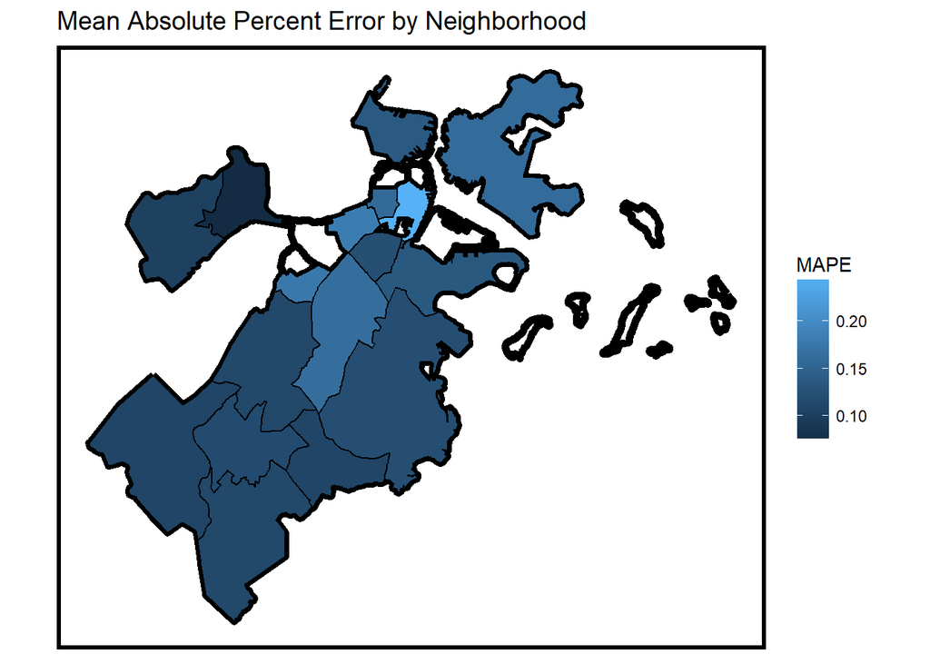

```r
ggplot() +
  geom_sf(data=bostonNhoods, aes(), fill=NA, colour="black", size=2) +
  geom_sf(data=error.Neighborhood, aes(fill=MAPE), colour="black") +
  labs(title="Mean Absolute Percent Error by Neighborhood") +
  mapTheme()
```

```r
pricebyNeighborhood <- boston.notest %>%
  group_by(Name) %>%
  summarise(meanPrice=mean(SalePrice),
            count=n()) %>%
  as.data.frame()
MAPE.neighborhood <- select(as.data.frame(error.Neighborhood),-geometry)
```

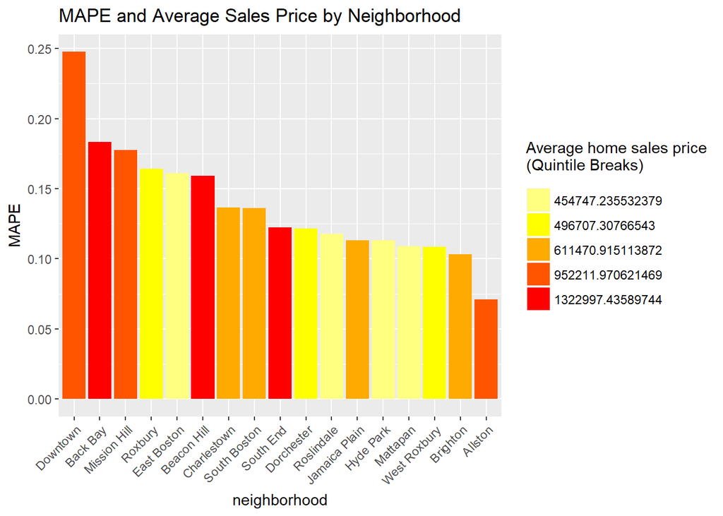

```r
ggplot(MAPE.neighborhood,
       aes(x=reorder(Name,-MAPE),y=MAPE,
           fill=factor(ntile(MAPE.neighborhood$meanPrice,5)))) +
  geom_bar(stat="identity") +
  scale_fill_manual(values = rev(heat.colors(5,1)),
                    labels=as.character(quantile(MAPE.neighborhood$meanPrice,
                                                   c(.1,.2,.4,.6,.8),na.rm=T)),
                    name="Average home sales price\n(Quintile Breaks)") +
  labs(x="neighborhood",
       title="MAPE and Average Sales Price by Neighborhood") +
  theme(axis.text.x = element_text(angle = 45, hjust = 1))
```

### 4.5 Spatial cross-validation

Spatial cross-validation allows us to test how generalizable our model is for rich, medium and poor neighborhoods. Thus, we ran three separate regression models, each time holding out one or two neighborhoods that have high, medium or low home sales price as test set. We use remaining observed values to build regression models to predict the home sales price in removed neighborhoods separately.

The results of APE and MAPE tell us how well our model is predicting. While the MAPE outcome seems to be lowest as a poor neighborhood removed, the MAPE outcome is highest as rich neighborhoods removed. This means that our model performs the best in a poor neighborhood, but the worst in rich neighborhoods.

```r
#neighborhoods with high home price
i <- which(boston.notest$Name %in% c("South End","Back Bay"))
training.high <- boston.notest[-i,]
test.high <- boston.notest[i,]

reg.high <- lm(log(SalePrice) ~.,data = training.high %>% select(-c(UniqueSale,Latitude,Longitude,test,PricePerSq,Name)))

residual.high <- data.frame(observed=test.high$SalePrice,
                            predicted=exp(predict(reg.high,test.high))) %>%
  transmute(APE=abs(predicted-observed)/observed,
            neighborhood="rich")

#neighborhoods with medium home price
i <- which(boston.notest$Name=="Dorchester")
training.middle <- boston.notest[-i,]
test.middle <- boston.notest[i,]

reg.middle <- lm(log(SalePrice) ~.,data = training.middle%>%select(-c(UniqueSale,Latitude,Longitude,test,PricePerSq,Name)))

residual.middle <- data.frame(observed=test.middle$SalePrice,
                              predicted=exp(predict(reg.middle,test.middle))) %>%
  transmute(APE=abs(predicted-observed)/observed,
            neighborhood="medium")

#neighborhoods with low home price
i <- which(boston.notest$Name=="Mattapan")
training.low <- boston.notest[-i,]
test.low <- boston.notest[i,]

reg.low <- lm(log(SalePrice) ~.,data = training.low %>% select(-c(UniqueSale,Latitude,Longitude,test,PricePerSq,Name)))

residual.low <- data.frame(observed=test.low$SalePrice,
                           predicted=exp(predict(reg.low,test.low))) %>%
  transmute(APE=abs(predicted-observed)/observed,
            neighborhood="poor")

spatial.cv <- rbind(residual.high,residual.middle,residual.low)
```

```r
data.frame(MAPE_rich=mean(residual.high$APE),
           MAPE_medium=mean(residual.middle$APE),
           MAPE_poor=mean(residual.low$APE))
```

```
##   MAPE_rich MAPE_medium MAPE_poor
## 1 0.1525651   0.1316604 0.1067379
```

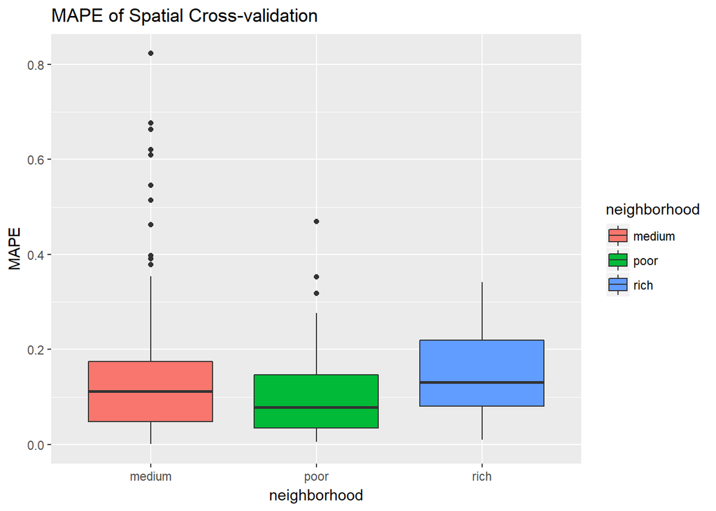

```r
ggplot(data = spatial.cv,aes(neighborhood,APE))+
  geom_boxplot(aes(fill=neighborhood)) +
  labs(y="MAPE",
       title="MAPE of Spatial Cross-validation")
```

## **Discussion**

In conclusion, more than 87.5% of the variation in home sales price can be explained by our regression model, and some predictors show more significant effect on sales price than others. Among predictors about the internal characteristics, total number of fire places and number of full baths in the house appears to be the most significant variables; and, among predictors about neighborhood features and demographics, distance to university, percent of owner occupied housing units and percent of minority are more significant. In addition, the spatial lag of home sales price has a very reliable predictor for home sales price.

On average, we may have approximately an average of 13% error when using this model to predict home sale price. The percent error is low when the predicted sale price is relatively low; however, the percent error increases as predicted value increased. Since the Moran’s I test result indicates no significant spatial clustering or disperse in regression residuals, this model is doing good in accounting for the spatial pattern of sales price.

Nevertheless, the model does not predict well in all regions. In some of the rich neighborhoods with higher home sales price, such as Downtown and Back Bay, we have percent errors mostly above 15%; in some of the poor neighborhoods with lower home sales price, the errors of prediction are lower than 12%. One of the causes for this discrepancy could be sample sizes are too small in rich neighborhoods. Another reason could be that predictors have different levels of impact on home sales price in different areas. However, our model is built to predict sales value in Boston area as a whole.

## **Conclusion**

We would recommend our model to Zillow for the following reasons. First, data sources of all predictors are accessible. The Home Interior Characteristics Dataset can be find on the Boston Assessing Department website, https://www.cityofboston.gov/assessing/search/. Data sources about neighborhood features and demographics come from the Census Bureau and Community Survey website, https://www.census.gov/programs-surveys/acs/. Additionally, the spatial lagged sales price predictor could be easily calculated with a sample of known home sales price. Second, we do not use local factors, such as name of neighborhood, as fixed effect. This allows our model to be adaptable in broader areas (if it is needed in the future), instead of being restrained in only Boston area. Last but not the least, our model is well-predicting for with low sales price (with approximately only 10% error), even though it does not perform well on high sales price.

To further improve our model, we suggest exploring additional predictors that may have significant effects on home sales price. Also, besides OLS regression, some other modeling methods are worth to be considered, such as geographically weighted regression. Geographically Weighted Regression (GWR) is a commonly used regression model when relationships between predictors and a dependent variable are varying spatially. GWR could be helpful for our model’s existing problem with inconstant predicting performance in different levels of home sales price.